# Dataset for the Summer Olympics from 1896-2012

> - Alanna Noguchi
> - DS 1.1

```python
import pandas as pd
import numpy as np
import matplotlib.pyplot as plt
import seaborn as sns

df = pd.read_csv('summer.csv')
df.head()
```

|  | Year | City | Sport | Discipline | Athlete | Country | Gender | Event | Medal |
| --- | --- | --- | --- | --- | --- | --- | --- | --- | --- |
| 0 | 1896 | Athens | Aquatics | Swimming | HAJOS, Alfred | HUN | Men | 100M Freestyle | Gold |
| 1 | 1896 | Athens | Aquatics | Swimming | HERSCHMANN, Otto | AUT | Men | 100M Freestyle | Silver |
| 2 | 1896 | Athens | Aquatics | Swimming | DRIVAS, Dimitrios | GRE | Men | 100M Freestyle For Sailors | Bronze |
| 3 | 1896 | Athens | Aquatics | Swimming | MALOKINIS, Ioannis | GRE | Men | 100M Freestyle For Sailors | Gold |
| 4 | 1896 | Athens | Aquatics | Swimming | CHASAPIS, Spiridon | GRE | Men | 100M Freestyle For Sailors | Silver |

```python
df.columns[:]
```

```
Index(['Year', 'City', 'Sport', 'Discipline', 'Athlete', 'Country', 'Gender',
       'Event', 'Medal'],
      dtype='object')
```

# What is the problem?

Women Athletes in Olympic sports.

# Let's begin with a visualization of the the ratio of Men to Women Olympians throughout the years

I unstacked the plot to see a better visualization of the men to women athletes. Here we can see that the Men to Women ratio is not even. Why is that?

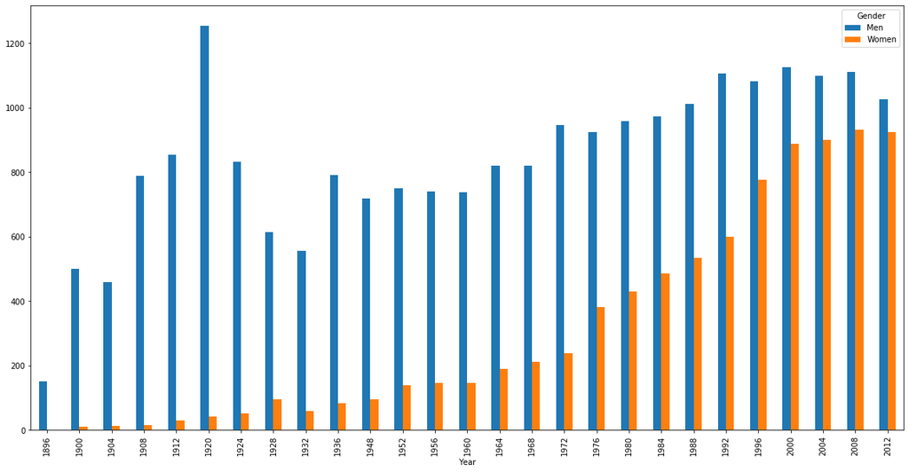

```python
df.groupby(['Year'])['Gender'].value_counts().unstack().plot(kind='bar',stacked=False, figsize=(20,10))
```

# We can see the number of Male to Female Olympic Medalists:

## Note: In 1896 there were no female athletes

> - The data here begins in 1896
> - It isn't until 1952, 56 years later than the number of Women Olympian Medialists is over 100.
> - In 1896, the number of Men Olypmic Athletes was already over 100 (151).

```python
athletes = pd.crosstab((df['Year']), df['Gender'])
athletes
```

| Gender Year | Men | Women |
| --- | --- | --- |
| 1896 | 151 | 0 |
| 1900 | 501 | 11 |
| 1904 | 458 | 12 |
| 1908 | 789 | 15 |
| 1912 | 855 | 30 |
| 1920 | 1255 | 43 |
| 1924 | 833 | 51 |
| 1928 | 615 | 95 |
| 1932 | 555 | 60 |
| 1936 | 791 | 84 |
| 1948 | 718 | 96 |
| 1952 | 750 | 139 |
| 1956 | 739 | 146 |
| 1960 | 737 | 145 |
| 1964 | 820 | 190 |
| 1968 | 819 | 212 |
| 1972 | 947 | 238 |
| 1976 | 924 | 381 |
| 1980 | 958 | 429 |
| 1984 | 973 | 486 |
| 1988 | 1011 | 535 |
| 1992 | 1105 | 600 |
| 1996 | 1082 | 777 |
| 2000 | 1126 | 889 |
| 2004 | 1099 | 899 |
| 2008 | 1110 | 932 |
| 2012 | 1025 | 924 |

# Research on the Olympics:

- the games were male exclusive
- The number of women competing at the Games has increased significantly over the last 30 years – from 26.1 per cent at Seoul 1988 to a record 45.2 per cent at Rio 2016 (online statistic)
- From the data in this dataset: in 1988 there a total of 1,546 medalists: 1011 Men and 535 Women. Of the medalists: 34.6% were women.
- Throughout the years, women sports have been introduced. Most recently: Rugby in 2016.

# Let's plot of the Number of Gold Medals won by Men and Women:

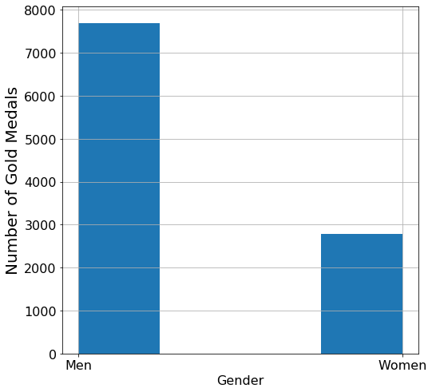

```python
df[df['Medal'] == 'Gold']['Gender'].hist(bins=4, figsize=(8,8))
plt.xlabel("Gender", fontsize=16)
plt.ylabel("Number of Gold Medals", fontsize=20)
plt.xticks(fontsize=16)
plt.yticks(fontsize=16)

# add legend, change colors, show values
```

# Let's see how many medals were won by year:

```python
table = pd.crosstab(df['Medal'], df['Year'])
table
```

| Year Medal | 1896 | 1900 | 1904 | 1908 | 1912 | 1920 | 1924 | 1928 | 1932 | 1936 | ... | 1976 | 1980 | 1984 | 1988 | 1992 | 1996 | 2000 | 2004 | 2008 | 2012 |
| --- | --- | --- | --- | --- | --- | --- | --- | --- | --- | --- | --- | --- | --- | --- | --- | --- | --- | --- | --- | --- | --- |
| Bronze | 40 | 142 | 123 | 211 | 284 | 355 | 285 | 242 | 196 | 282 | ... | 447 | 472 | 500 | 535 | 596 | 634 | 685 | 679 | 710 | 680 |
| Gold | 64 | 178 | 188 | 311 | 301 | 497 | 301 | 229 | 213 | 299 | ... | 429 | 460 | 483 | 506 | 558 | 615 | 663 | 659 | 669 | 636 |
| Silver | 47 | 192 | 159 | 282 | 300 | 446 | 298 | 239 | 206 | 294 | ... | 429 | 455 | 476 | 505 | 551 | 610 | 667 | 660 | 663 | 633 |

3 rows × 27 columns

# Here we can see the total number of Medalists by gender per each sport throughout the years:

- notice that there were 0 women athletes for Rugby. Remember that is was only available for women to compete in this sport beginning in 2016.

```python
table1 = pd.crosstab((df['Sport']), df['Gender'])
table1
```

| Gender Sport | Men | Women |
| --- | --- | --- |
| Aquatics | 2444 | 1726 |
| Archery | 218 | 111 |
| Athletics | 2475 | 1163 |
| Badminton | 72 | 72 |
| Baseball | 335 | 0 |
| Basketball | 653 | 359 |
| Basque Pelota | 4 | 0 |
| Boxing | 882 | 12 |
| Canoe | 54 | 27 |
| Canoe / Kayak | 774 | 228 |
| Cricket | 24 | 0 |
| Croquet | 8 | 0 |
| Cycling | 969 | 136 |
| Equestrian | 741 | 198 |
| Fencing | 1297 | 316 |
| Football | 1233 | 264 |
| Golf | 27 | 3 |
| Gymnastics | 1508 | 799 |
| Handball | 544 | 429 |
| Hockey | 991 | 431 |
| Ice Hockey | 27 | 0 |
| Jeu de paume | 3 | 0 |
| Judo | 323 | 168 |
| Lacrosse | 59 | 0 |
| Modern Pentathlon | 168 | 12 |
| Polo | 66 | 0 |
| Rackets | 10 | 0 |
| Roque | 3 | 0 |
| Rowing | 2016 | 651 |
| Rugby | 192 | 0 |
| Sailing | 1000 | 109 |
| Shooting | 1022 | 128 |
| Skating | 15 | 12 |
| Softball | 0 | 180 |
| Table Tennis | 72 | 72 |
| Taekwondo | 56 | 56 |
| Tennis | 176 | 120 |
| Triathlon | 12 | 12 |
| Tug of War | 94 | 0 |
| Volleyball | 497 | 497 |
| Water Motorsports | 5 | 0 |
| Weightlifting | 509 | 84 |
| Wrestling | 1168 | 44 |

# Great News: The Number of Women Olympians Has Increased Throughout The Years

But still, women are not allowed to compete in every sport

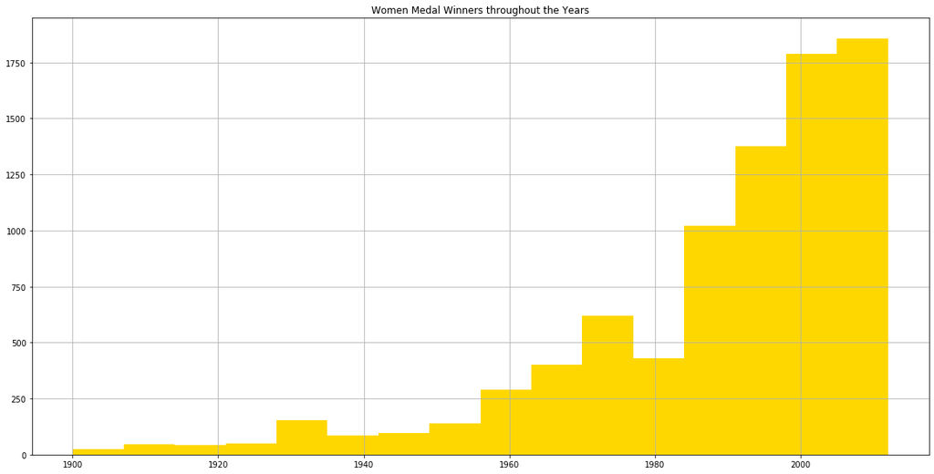

```python
plt.title('Women Medal Winners throughout the Years')
apps_track_rating = df[(df['Gender'] == 'Women') & (df['Medal'])]
apps_track_rating['Year'].hist(bins = 16, color='gold', figsize=(20, 10))
```

# As the data shows, the number of women athletes has increased throughout the years.

# Now let's see the distribution of medals won by Country

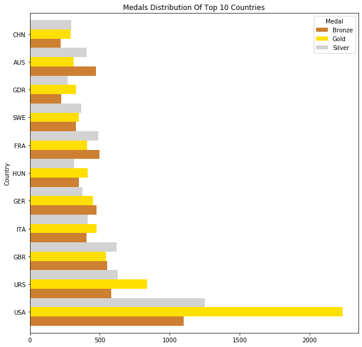

```python
medals_by_country = df.groupby(['Country','Medal'])['Gender'].count().reset_index().sort_values(by='Gender',ascending=False)
medals_by_country = medals_by_country.pivot('Country','Medal','Gender').fillna(0)
top_ten = medals_by_country.sort_values(by='Gold',ascending=False)[:11] # show the top 10
top_ten.plot.barh(width=1.0,color=['#CD7F32','#FFDF00','#D3D3D3'])
fig=plt.gcf()
fig.set_size_inches(10, 10)
plt.title('Medals Distribution Of Top 10 Countries')
plt.show()
```

# We see that the USA has the most number of medals won, let's find out more about the USA

```python
#slice the data to only include the usa
usa = df.loc[df["Country"] == "USA"]
```

## The number of Medals and Types USA Won Throughout the Years:

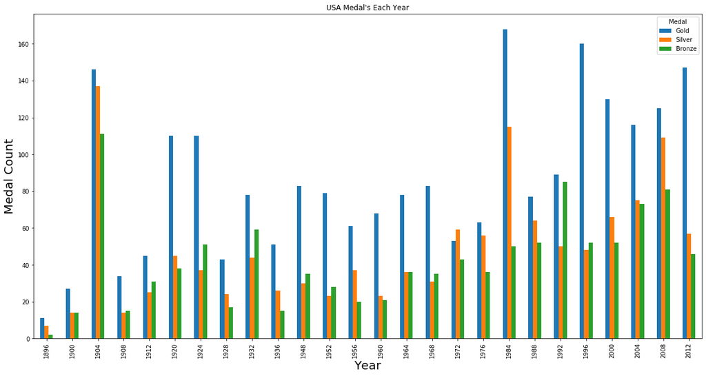

```python
medals_years = pd.DataFrame({"tally" : usa.groupby(["Year", "Medal"]).size()}).reset_index()
pivoted = medals_years.pivot(index="Year", columns="Medal", values="tally")
axis = pivoted[["Gold", "Silver", "Bronze"]].plot(kind="bar", title="USA Medal's Each Year", figsize=(20, 10))
axis.set_xlabel("Year", fontsize= 20)
axis.set_ylabel("Medal Count", fontsize= 20)
plt.show()
```

# US Top Male Athlete:

Michael Phelps with 22 medals

```python
usa[usa['Gender']=='Men']['Athlete'].value_counts()
```

```
PHELPS, Michael            22
SPITZ, Mark                11
LOCHTE, Ryan               11
OSBURN, Carl Townsend      11
BIONDI, Matthew            11
                           ..
SPELLMAN, John Franklin     1
LOOMIS, Frank               1
BACH, Michael               1
ERKER, August               1
GLANCY, Harrison Smith      1
Name: Athlete, Length: 2284, dtype: int64
```

# Where did he get his medals from?

> - From this dataset, Phelps competed in 2004, 2008, and 2012

```python
usa[(usa['Athlete'] == 'PHELPS, Michael') & (usa['Medal'])]
```

|  | Year | City | Sport | Discipline | Athlete | Country | Gender | Event | Medal |
| --- | --- | --- | --- | --- | --- | --- | --- | --- | --- |
| 25225 | 2004 | Athens | Aquatics | Swimming | PHELPS, Michael | USA | Men | 100M Butterfly | Gold |
| 25253 | 2004 | Athens | Aquatics | Swimming | PHELPS, Michael | USA | Men | 200M Butterfly | Gold |
| 25258 | 2004 | Athens | Aquatics | Swimming | PHELPS, Michael | USA | Men | 200M Freestyle | Bronze |
| 25265 | 2004 | Athens | Aquatics | Swimming | PHELPS, Michael | USA | Men | 200M Individual Medley | Gold |
| 25277 | 2004 | Athens | Aquatics | Swimming | PHELPS, Michael | USA | Men | 400M Individual Medley | Gold |
| 25286 | 2004 | Athens | Aquatics | Swimming | PHELPS, Michael | USA | Men | 4X100M Freestyle Relay | Bronze |
| 25325 | 2004 | Athens | Aquatics | Swimming | PHELPS, Michael | USA | Men | 4X100M Medley Relay | Gold |
| 25361 | 2004 | Athens | Aquatics | Swimming | PHELPS, Michael | USA | Men | 4X200M Freestyle Relay | Gold |
| 27224 | 2008 | Beijing | Aquatics | Swimming | PHELPS, Michael | USA | Men | 100M Butterfly | Gold |
| 27252 | 2008 | Beijing | Aquatics | Swimming | PHELPS, Michael | USA | Men | 200M Butterfly | Gold |
| 27258 | 2008 | Beijing | Aquatics | Swimming | PHELPS, Michael | USA | Men | 200M Freestyle | Gold |
| 27264 | 2008 | Beijing | Aquatics | Swimming | PHELPS, Michael | USA | Men | 200M Individual Medley | Gold |
| 27276 | 2008 | Beijing | Aquatics | Swimming | PHELPS, Michael | USA | Men | 400M Individual Medley | Gold |
| 27291 | 2008 | Beijing | Aquatics | Swimming | PHELPS, Michael | USA | Men | 4X100M Freestyle Relay | Gold |
| 27327 | 2008 | Beijing | Aquatics | Swimming | PHELPS, Michael | USA | Men | 4X100M Medley Relay | Gold |
| 27366 | 2008 | Beijing | Aquatics | Swimming | PHELPS, Michael | USA | Men | 4X200M Freestyle Relay | Gold |
| 29270 | 2012 | London | Aquatics | Swimming | PHELPS, Michael | USA | Men | 100M Butterfly | Gold |
| 29298 | 2012 | London | Aquatics | Swimming | PHELPS, Michael | USA | Men | 200M Butterfly | Silver |
| 29309 | 2012 | London | Aquatics | Swimming | PHELPS, Michael | USA | Men | 200M Medley | Gold |
| 29340 | 2012 | London | Aquatics | Swimming | PHELPS, Michael | USA | Men | 4X100M Freestyle | Silver |
| 29370 | 2012 | London | Aquatics | Swimming | PHELPS, Michael | USA | Men | 4X100M Medley | Gold |
| 29405 | 2012 | London | Aquatics | Swimming | PHELPS, Michael | USA | Men | 4X200M Freestyle | Gold |